# Upgrading to auto tiles

By this point we have a bare minimum level generator that uses one boxy tile type.

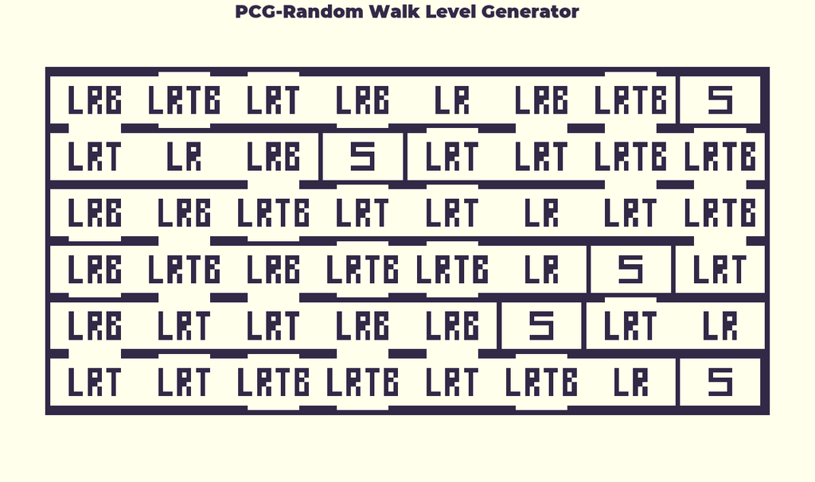

In this lesson we’ll use the auto tile feature to make our level more appealing as you can see here.

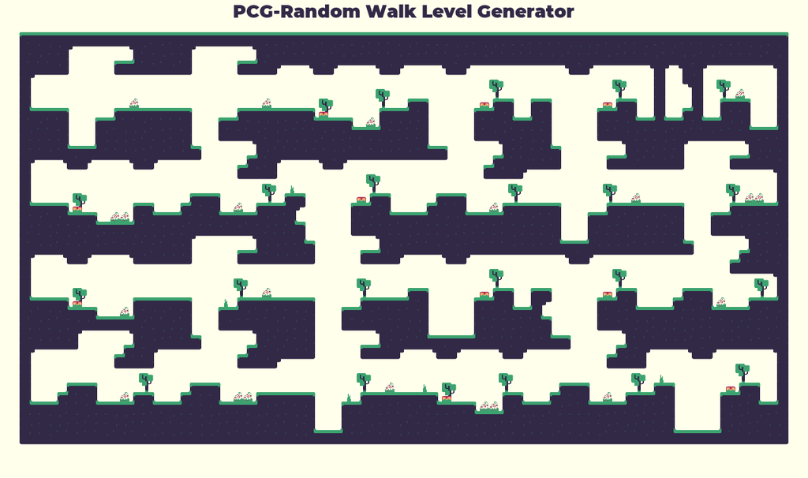

We’ll also allow for other types of assets such as chests.

Adding more assets gives us more flexibility when building rooms because we can include sprites or other interactive objects and stack them on top of the *TileMap*.

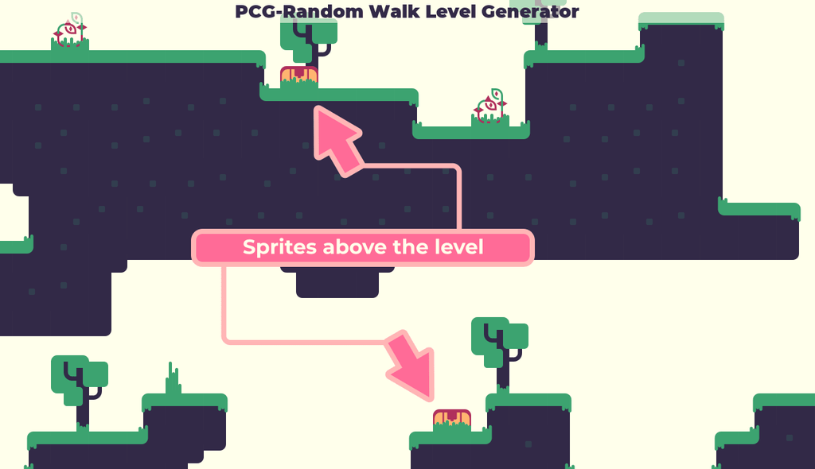

## Updating the tile set

We have prepared a tile set which has ground and vegetation auto tiles along with some single tiles we can use to fill out the rooms.

Update the *Tile Set* property in the *Inspector* for all *TileMaps* from both *RandomWalker* and *Rooms* scenes to use the `RandomWalker/Levels/tileset.tres` instead.

Feel free to explore this tile set in Godot’s *TileSet* docker before moving on but be careful not to redraw any tile regions.

Update each room to use the new tile set like in the example below.

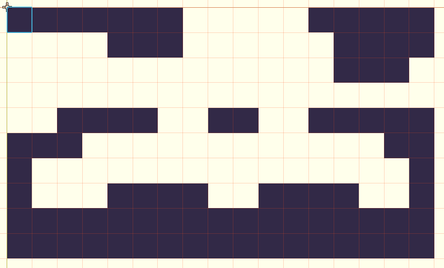

[figure not shown]

Be sure to add a few *Maybe** tiles. These tiles have a chance at being placed to add variety to the rooms.

## Updating placement functions

Since our auto tiles use a `2×2` bitmask let’s first widen the level border walls by 2 in `_place_walls()` function from `RandomWalker.gd`.

```
func _place_walls(type: int = 0) -> void:
    var cell_grid_size := _grid_to_map(grid_size)

    for x in [-2, -1, cell_grid_size.x, cell_grid_size.x + 1]:
        for y in range(-2, cell_grid_size.y + 2):
            level.set_cell(x, y, type)

    for x in range(-1, cell_grid_size.x + 2):
        for y in [-2, -1, cell_grid_size.y, cell_grid_size.y + 1]:
            level.set_cell(x, y, type)
```

If Godot can’t find matching auto tiles based on the bitmask, it will default to using the tile set as the icon in the *TileSet* docker.

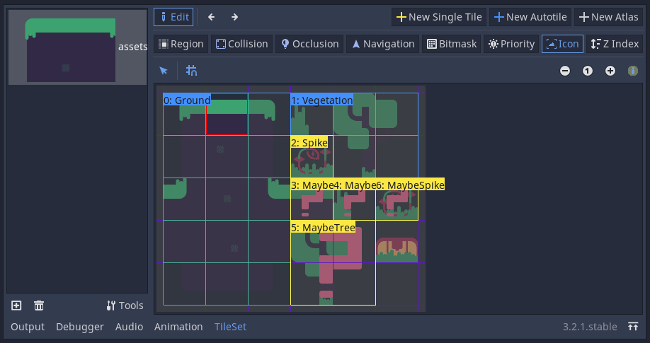

Increasing the thickness of the outer walls fixes the possible problem shown in the next picture.

[figure not shown]

We also need to call `level.update_bitmask_region()` at the end of `_place_side_rooms()` to refresh the *TileMap* so that Godot properly render the auto tiles.

```
func _place_side_rooms() -> void:
    yield(self, "path_completed")
    var rooms_max_index: int = _rooms.Type.size() - 1
    for key in _state.empty_cells:
        var type := _rng.randi_range(0, rooms_max_index)
        _copy_room(key, type)
    level.update_bitmask_region()
```

## Updating the Rooms script

Before updating `_copy_room()` let’s update `_get_room_data()` from `Rooms.gd` since `_copy_room()` will depend on it.

Open `Rooms.gd` in the script editor and define the following enumeration below `enum Type`:

```
enum Cell { GROUND, VEGETATION, SPIKES, MAYBE_GROUND, MAYBE_BUSH, MAYBE_TREE, MAYBE_SPIKES }
```

These are the tile types corresponding to the indices in *tileset.tres*.

For example `Cell.GROUND` is `0` and corresponds to the *Ground* auto tile while `Cell.MAYBE_TREE` corresponds to the *MaybeTree* single tile. These will be used to map static & probabilistic tiles. To do that, define the following constant:

```
const CELL_MAP := {
    Cell.GROUND: {"chance": 1.0, "cell": [[Cell.GROUND]], "size": Vector2.ONE},
    Cell.VEGETATION: {"chance": 1.0, "cell": [[Cell.VEGETATION]], "size": Vector2.ONE},
    Cell.SPIKES: {"chance": 1.0, "cell": [[Cell.SPIKES]], "size": Vector2.ONE},
    Cell.MAYBE_GROUND: {"chance": 0.7, "cell": [[Cell.GROUND]], "size": Vector2.ONE},
    Cell.MAYBE_BUSH: {"chance": 0.3, "cell": [[Cell.VEGETATION]], "size": Vector2.ONE},
    Cell.MAYBE_TREE:
    {
        "chance": 0.8,
        "cell": [[Cell.VEGETATION, Cell.VEGETATION], [Cell.VEGETATION, Cell.VEGETATION]],
        "size": 2 * Vector2.ONE
    },
    Cell.MAYBE_SPIKES: {"chance": 0.5, "cell": [[Cell.SPIKES]], "size": Vector2.ONE}
}
```

Static tiles have the `chance` key set to `1.0` while probabilistic tiles have `chance` set to something other than `1.0`.

Let’s take `Cell.MAYBE_TREE` as an example.

```
Cell.MAYBE_TREE:
{
    "chance": 0.8,
    "cell": [[Cell.VEGETATION, Cell.VEGETATION], [Cell.VEGETATION, Cell.VEGETATION]],
    "size": 2 * Vector2.ONE
},
```

`Cell.MAYBE_TREE` corresponds to *MaybeTree* single tile. This is mapped to `Cell.VEGETATION` which, in turn, corresponds to the *Vegetation* auto tile.

We previously set up the `2×2` bitmask on the *Vegetation* auto tile such that when four tiles of this type are touching in a square, it results in a tree. You can see the red bitmask which shows this in the picture below.

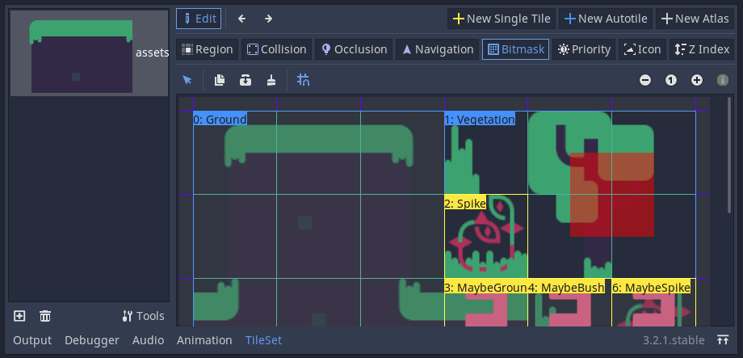

To capture this outcome, we use the `size` key which defines the size on `X` and `Y` for the array stored in the `cell` key.

Let’s update `_get_room_data()` to allow for the probabilistic tiles.

```
func get_room_data(type: int) -> Dictionary:
    var group: Node2D = get_child(type)
    var index := _rng.randi_range(0, group.get_child_count() - 1)
    var room: TileMap = group.get_child(index)

    var data := {"objects": [], "tilemap": []}
    for object in room.get_children():
        data.objects.push_back(object)

    for v in room.get_used_cells():
        var mapping: Dictionary = CELL_MAP[room.get_cellv(v)]
        if _rng.randf() > mapping.chance:
            continue

        for x in range(mapping.size.x):
            for y in range(mapping.size.y):
                data.tilemap.push_back({"offset": v + Vector2(x, y), "cell": mapping.cell[x][y]})
    return data
```

The first part of the function remains the same, but we want to differentiate between other interactive objects and *TileMap* cells so we return a dictionary instead of an array. For this we define `var data := {"objects": [], "tilemap": []}`.

We first iterate over any child nodes in this `room` and add them to the `data.objects` array in our data dictionary.

```
for object in room.get_children():
    data.objects.push_back(object)
```

We then iterate over the used cells in this `room`’s *TileMap*. For each of these, we generate a random number and if it’s greater than the chance for this cell type, we skip it.

```
for v in room.get_used_cells():
    var mapping: Dictionary = CELL_MAP[room.get_cellv(v)]
    if _rng.randf() > mapping.chance:
        continue
```

For example if `_rng.randf() > CELL_MAP[Cell.MAYBE_TREE].chance` is true, the random number is greater than `0.8` so we skip this tile and don’t include the tree *Vegetation* auto tiles in this data set.

If the check fails, we include the mapped cells in the `data.tilemap` based on it’s `size` key.

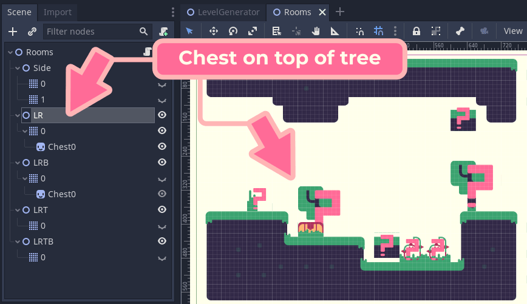

## Fixing the copy room function

We have one final step to finish the project. We need to fix `_copy_room()` in `RandomWalker.gd` to take into account the new `data` dictionary from `_get_room_data()`. We now have to duplicate the interactive objects as well as copy the *TileMap* data.

```
func _copy_room(offset: Vector2, type: int) -> void:
    var world_offset := _grid_to_world(offset)
    var map_offset := _grid_to_map(offset)
    var data: Dictionary = _rooms.get_room_data(type)

    for object in data.objects:
        var new_object: Node2D = object.duplicate()
        new_object.position += world_offset
        level.add_child(new_object)

    for d in data.tilemap:
        level.set_cellv(map_offset + d.offset, d.cell)
```

We do this in the first loop by going over the elements in `data.objects`. We duplicate each object and place it at the proper coordinates, in pixels.